# R Notebook

```r
library(MASS)
library(MVN)
library(biotools)
library(readxl)
library(ggplot2)
library(tidyverse)
library(caret)
```

```r
data13 <- read_excel("C:/Users/lili/Downloads/data13.xlsx",sheet="Sheet2")
knitr::kable(head(data13, 10))
```

| GPA | GMAT | admit |
| --- | --- | --- |
| 2.96 | 596 | 1 |
| 3.14 | 473 | 1 |
| 3.22 | 482 | 1 |
| 3.29 | 527 | 1 |
| 3.69 | 505 | 1 |
| 3.46 | 693 | 1 |
| 3.03 | 626 | 1 |
| 3.19 | 663 | 1 |
| 3.63 | 447 | 1 |
| 3.59 | 588 | 1 |

```r
data13$admit <- as.factor(data13$admit)
summary(data13)
```

```
      GPA            GMAT     admit
 Min.   :2.13   Min.   :313   1:31
 1st Qu.:2.60   1st Qu.:425   2:28
 Median :3.01   Median :482   3:26
 Mean   :2.97   Mean   :488
 3rd Qu.:3.30   3rd Qu.:538
 Max.   :3.80   Max.   :693
```

```r
mnv <- manova(cbind(GPA,GMAT)~admit, data=data13)
summary(mnv)
```

```
          Df Pillai approx F num Df den Df Pr(>F)
admit      2   1.01     41.8      4    164 <2e-16 ***
Residuals 82
---
Signif. codes:  0 ‘***’ 0.001 ‘**’ 0.01 ‘*’ 0.05 ‘.’ 0.1 ‘ ’ 1
```

Terlihat bahwa tolak H0 sehingga ada perbedaan yang signifikan

#Uji Homogenitas H0 : ∑1=∑2=∑3 H1 : Minimal ada satu yang berbeda

```r
boxM(data13[,-3],data13$admit)
```

```
    Box's M-test for Homogeneity of Covariance Matrices

data:  data13[, -3]
Chi-Sq (approx.) = 16, df = 6, p-value = 0.01
```

Terlihat bahwa tidak memenuhi asumsi homogenitas (tolak H0). Namun pada tutorial kali ini akan dianggap memenuhi asumsi homogenitas.

#Uji Normalitas

```r
mvn(data13[, -3])
```

| Test | HZ | p value | MVN |
| --- | --- | --- | --- |
| Henze-Zirkler | 1.14 | 0.0153 | NO |

|  | Test | Variable | Statistic | p value | Normality |
| --- | --- | --- | --- | --- | --- |
| 1 | Anderson-Darling | GPA | 0.576 | 0.131 | YES |
| 2 | Anderson-Darling | GMAT | 0.465 | 0.248 | YES |

|  | n | Mean | Std.Dev | Median | Min | Max | 25th | 75th | Skew | Kurtosis |
| --- | --- | --- | --- | --- | --- | --- | --- | --- | --- | --- |
| GPA | 85 | 2.97 | 0.429 | 3.01 | 2.13 | 3.8 | 2.6 | 3.3 | -0.0483 | -1.009 |
| GMAT | 85 | 488.45 | 81.522 | 482.00 | 313.00 | 693.0 | 425.0 | 538.0 | 0.3885 | -0.136 |

```
NA
```

```r
set.seed(123)
k <- length(levels(data13$admit))
n <- nrow(data13)
# data training sebanyak
idx <- sample(1:n, 36)
data13.tr <- data13[idx,] #data training
data13.ts <- data13[-idx,] #data testing
# Analisis Diskriminan
fit<-lda(admit~.,data=data13.tr)
# Output dari analisis diskriminan
fit
```

```
Call:
lda(admit ~ ., data = data13.tr)

Prior probabilities of groups:
    1     2     3
0.278 0.361 0.361

Group means:
   GPA GMAT
1 3.43  585
2 2.52  462
3 2.92  458

Coefficients of linear discriminants:
          LD1     LD2
GPA  -5.86111  2.2030
GMAT -0.00979 -0.0154

Proportion of trace:
   LD1    LD2
0.9724 0.0276
```

Prior : Jumlah sampel yg masuk Jumlah sampel yang masuk 28% dari group 1, 36% dari group 2, 36% dari group 3

Means : rata-rata tiap kelompok. Rata-rata GPA group1 adalah 3.4, group2 adalah 2.5, group3 adalah 2.9 Rata-rata GMAT group1 adalah 585.4, group2 adalah 461.53, group3 adalah 457.84

koefisien diskriminannya LD1 : -5.86GPA - 0.0098GMAT LD2 = 2.2GPA - 0.015GMAT

proporsi of trace : proporsi menjelaskan LD1 menjelaskan 97% dari data, sedangkan LD2 menjelaskan 3% dari data

```r
zscore <- predict(fit,data13[,-3])
knitr::kable(head(zscore$x, 10))
```

| LD1 | LD2 |
| --- | --- |
| -1.25 | -1.467 |
| -1.10 | 0.826 |
| -1.66 | 0.863 |
| -2.51 | 0.324 |
| -4.64 | 1.544 |
| -5.13 | -1.861 |
| -1.95 | -1.775 |
| -3.25 | -1.993 |
| -3.72 | 2.306 |
| -4.86 | 0.044 |

```r
kor1 <- t(cor(zscore$x[,1],data13[,-3]))
kor2 <- t(cor(zscore$x[,2],data13[,-3]))
tabkor<-data.frame(kor1,kor2)
tabkor
```

|  | kor1 | kor2 |
| --- | --- | --- |
| GPA | -0.971 | 0.312 |
| GMAT | -0.659 | -0.700 |

```r
pred <- predict(fit,data13.ts[,-3])
pred
```

```
$class
 [1] 3 3 3 1 1 1 1 1 1 1 1 1 1 1 1 1 1 3 1 1 1 2 2 2 2 2 2 2 2 2 2 2 2 2 3 3 3 3 3 3 1 3 3 3 3 3 3 3 3
Levels: 1 2 3

$posterior
          1        2        3
1  2.42e-01 5.25e-03 7.52e-01
2  2.36e-02 1.08e-03 9.75e-01
3  1.96e-01 2.31e-04 8.04e-01
4  9.32e-01 4.37e-06 6.75e-02
5  1.00e+00 3.55e-12 2.67e-05
6  1.00e+00 1.97e-13 1.83e-07
7  1.00e+00 4.44e-08 4.34e-04
8  9.92e-01 3.30e-07 8.08e-03
9  9.99e-01 1.30e-08 1.44e-03
```

[output cut: 92 more lines]

Posterior : peluang masuk kelas, diambil yang terbesar di setiap observasi.

```r
lda.data <- cbind(data13.tr, predict(fit)$x)
ggplot(lda.data, aes(LD1, LD2)) +
geom_point(aes(color = as.factor(admit))) +
theme_minimal()
```

[output not shown]

```r
sum(diag(prop.table(ct)))
```

```
[1] 0.857
```

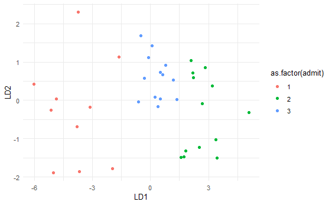

```r
lda.data <- cbind(data13.tr, predict(fit)$x)
ggplot(lda.data, aes(LD1, LD2)) +
geom_point(aes(color = as.factor(admit))) +
theme_minimal()
```

```r
GPA = c(3.21,2.93)
GMAT = c(562,619)
data <- as.data.frame(cbind(GPA,GMAT))
data
```

| GPA | GMAT |
| --- | --- |
| 3.21 | 562 |
| 2.93 | 619 |

```r
predict(fit,data)
```

```
$class
[1] 1 3
Levels: 1 2 3

$posterior
      1        2      3
1 0.937 1.08e-05 0.0625
2 0.360 5.89e-03 0.6340

$x
    LD1    LD2
1 -2.38 -0.392
2 -1.30 -1.887
```